# First evidence of mixotrophy in known phototrophic haptophyte, Phaeocystis antarctica, and their interaction with known predator Ross Sea Dinoflagellate

## By: Chris Carnivale

# Introduction (VERY rough intro that is)

Ross Sea Dinoflagellate (RSD) is an undescribed dinoflagellate originally isolated in the Ross Sea of Antarctica. RSD is a kleptoplastidic mixotrophic phytoflagellate, which retains the chloroplasts of the algae it consumes. Most kleptoplastidic plankton can only retain the chloroplasts for days to weeks and need to continually feed to replenish their chloroplasts. RSD, however, can retain chloroplasts for their very specific prey, *Phaeocystis antarctica* for up to 6 months. It is known that RSD is planktivorous but it is unknown if it is also bacterivorous. Here, we test if RSD also consumes bacteria, while showing the first evidence that their plankton prey are also mixotrophic. Our null hypothesis: There is no difference of bacterial ingestion between light levels for Ross Sea Dinoflagellate. Any observes differences occur stochastically and due to chance. There is no difference of bacterial ingestion between light levels for *Phaeocystis antarctica*. Any observes differences occur stochastically and due to chance. There is no difference of bacterial ingestion between 21 and 77 days for Ross Sea Dinoflagellate. Any observes differences occur stochastically and due to chance. Any differences occur stochastically. There is no difference of bacterial ingestion between 21 and 77 days for *Phaeocystis antarctica*. Any observes differences occur stochastically and due to chance. Alpha is set at 0.05.

# Methods (VERY rough intro that is)

RSD cultures are maintained in fresh artificial seawater with additional f/2 nutrient rich media with its prey, phaeocystis. They cannot be grown and maintained alone for prolonged periods. In order to determine ingestion rates, RSD cultures were inoculated with 0.6 um flourescent microspheres at a concentration of 1 x 10^5. This concentration is aprroximately 10-20% of the bacterial standing stock concentration. RSD experimental cultures were exposed to 3 different light levels: dark, regular (1 x 10^15 quanta per m^2 per sec), and high (1 x 10^15 quanta per m^2 per sec). Feeding experiments were done at 2 different times; once after 21 days and again after 77 days with replicates. To analyze the data, 2 way anovas were performed for each species with “time” and “light level” as the two factors. 2-way anova was chosen to compare multiple means against 2 different factors. After a post-hoc analysis Tukey’s HSD was used to determine which of the means were different from each other. Tukey’s HSD was chosen as there are no clear “control” groups as we would like to compare all possible permutations of means.

# Results

```r
phaeo_rsd_ing_2 <- filter(phaeo_rsd_ing_1, treatment_time == c("Months", "Weeks"))
```

[output not shown]

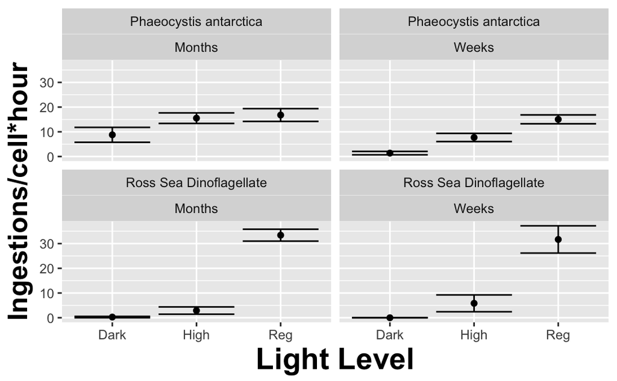

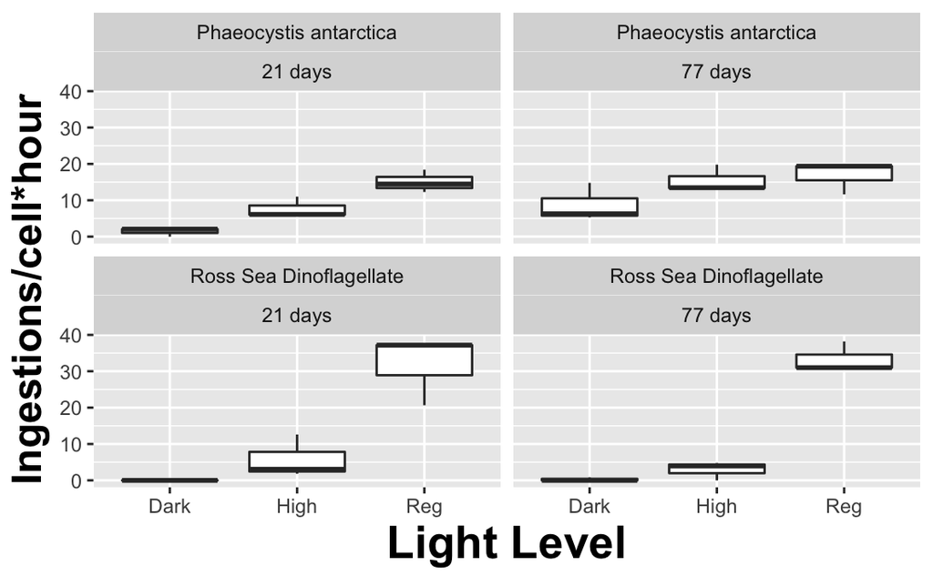

```r
phaeo_tukey
```

```
  Tukey multiple comparisons of means
    95% family-wise confidence level
    factor levels have been ordered

Fit: aov(formula = ing_percell_perhour ~ treatment_light * treatment_time, data = phaeo_ing)

$treatment_light
               diff        lwr       upr     p adj
High-Dark  6.535457  0.9021309 12.168783 0.0233792
Reg-Dark  10.835339  5.2020128 16.468665 0.0006717
Reg-High   4.299882 -1.3334442  9.933208 0.1458257

$treatment_time
                 diff      lwr      upr     p adj
Months-Weeks 5.653927 1.897495 9.410359 0.0065874

$`treatment_light:treatment_time`
                             diff       lwr      upr     p adj
High:Weeks-Dark:Weeks    6.331053 -3.699296 16.36140 0.3391685
Dark:Months-Dark:Weeks   7.404225 -2.626124 17.43457 0.2046305
Reg:Weeks-Dark:Weeks    13.665190  3.634842 23.69554 0.0064674
High:Months-Dark:Weeks  14.144086  4.113738 24.17444 0.0049665
Reg:Months-Dark:Weeks   15.409713  5.379364 25.44006 0.0025010
Dark:Months-High:Weeks   1.073172 -8.957176 11.10352 0.9989930
Reg:Weeks-High:Weeks     7.334138 -2.696211 17.36449 0.2118701
High:Months-High:Weeks   7.813034 -2.217315 17.84338 0.1663988
Reg:Months-High:Weeks    9.078660 -0.951689 19.10901 0.0847983
Reg:Weeks-Dark:Months    6.260965 -3.769384 16.29131 0.3497426
High:Months-Dark:Months  6.739861 -3.290488 16.77021 0.2818475
Reg:Months-Dark:Months   8.005487 -2.024861 18.03584 0.1506354
High:Months-Reg:Weeks    0.478896 -9.551453 10.50924 0.9999807
Reg:Months-Reg:Weeks     1.744522 -8.285827 11.77487 0.9902536
Reg:Months-High:Months   1.265626 -8.764723 11.29597 0.9977896
```

# Conclusions